# Assignment_3_Time_Series

Pulling the jena_climate_2009_2016.csv from amazon s3 and unzipping the file to the same directory where we are in. Commenting the code as it has already been done

```python
# !wget https://s3.amazonaws.com/keras-datasets/jena_climate_2009_2016.csv.zip
# !unzip jena_climate_2009_2016.csv.zip
```

Importing all the packages required

```python
import os
import numpy as np
import pandas as pd
from tensorflow import keras
import matplotlib.pyplot as plt
from tensorflow.keras import layers, Sequential
```

```python
# Looking at the contents of the data and temperature is present in the 3rd column
data_dir = ''
fname = os.path.join(data_dir, 'jena_climate_2009_2016.csv')
f = open(fname)
data = f.read()
f.close()
lines = data.split('\n')
header = lines[0].split(',')
lines = lines[1:]
print(header)
print(len(lines))
```

```
['"Date Time"', '"p (mbar)"', '"T (degC)"', '"Tpot (K)"', '"Tdew (degC)"', '"rh (%)"', '"VPmax (mbar)"', '"VPact (mbar)"', '"VPdef (mbar)"', '"sh (g/kg)"', '"H2OC (mmol/mol)"', '"rho (g/m**3)"', '"wv (m/s)"', '"max. wv (m/s)"', '"wd (deg)"']
420451
```

I am going to assign temp variabe to the temperature values which are in the 3rd column which is at python index 1 after removing the first column. Also assigning the float data here to all the rows except the first column

```python
float_data = np.zeros((len(lines), len(header) - 1))
temp = np.zeros((len(lines),))
for i, line in enumerate(lines):
    values = [float(x) for x in line.split(',')[1:]]
    temp[i] = values[1]
    float_data[i, :] = values
```

Plotting the temperature over time

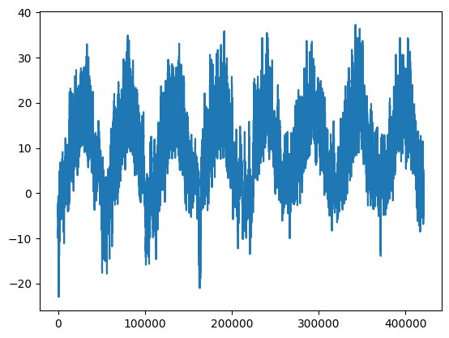

```python
plt.plot(range(len(temp)), temp)
```

Plotting the temperature for the first 10 days to see if there is pure seasonality and it seems like there is in the later part of the 10 days,

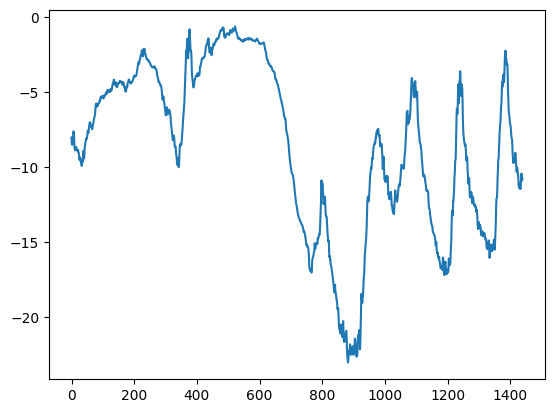

```python
plt.plot(range(1440), temp[:1440])
```

Dividing the number of samples of entire data into training(50%), validation(25%) and testing(25%) datasets

```python
# Define the proportions for train, validation, and test sets
train_proportion = 0.5
val_proportion = 0.25
test_proportion = 1 - train_proportion - val_proportion

# Calculate the number of samples for each set
train_samples = int(train_proportion * len(float_data))
val_samples = int(val_proportion * len(float_data))
test_samples = len(float_data) - train_samples - val_samples

# Print the number of samples for each set
print(train_samples)
print(val_samples)
print(test_samples)
```

```
210225
105112
105114
```

There will be around **210225** samples in training dataset, **105112** samples in validation dataset and **105114** samples in test dataset

We now normalize the float data which has all the contents of the dataset before we split them into the train, valid and test datasets

```python
mean = float_data[:train_samples].mean(axis=0)
float_data -= mean
std = float_data[:train_samples].std(axis=0)
float_data /= std
```

This code is splitting up entire dataset for a RNN time series forecasting problem.

The sampling_rate is defined as 6, indicating the rate at which data points are collected.

sequence_length is set to 120, representing the length of each sequence used for prediction.

delay is calculated based on the sampling rate and sequence length.

The batch_size is set to 256, determining how many samples are processed together during training.

Three datase ts (train, validation, and test) are created using the timeseries_dataset_from_array function.

These datasets are derived from the float_data array and corresponding targets, with appropriate sampling rates, sequence lengths, and batch sizes.

This setup is essential for training and evaluating models on time series data.

```python
sampling_rate = 6
sequence_length = 120

# In this equation, delay is being calculated based on the sampling_rate, sequence_length, and a fixed value of 24.
# It represents the time gap between the input data and the corresponding target for each
# sample in the dataset. This delay is crucial for aligning the input and output correctly
# during training, ensuring that the model learns to make accurate predictions based on
#historical data. The -1 term in the equation is used to account for the fact that indexing starts from zero.
delay = sampling_rate * (sequence_length + 24 - 1)
batch_size = 256

train_dataset = keras.utils.timeseries_dataset_from_array(
    float_data[:-delay],
    targets=temp[delay:],
    sampling_rate=sampling_rate,
    sequence_length=sequence_length,
    shuffle=True,
    batch_size=batch_size,
    start_index=0,
    end_index=train_samples)

val_dataset = keras.utils.timeseries_dataset_from_array(
    float_data[:-delay],
    targets=temp[delay:],
    sampling_rate=sampling_rate,
    sequence_length=sequence_length,
    shuffle=True,
    batch_size=batch_size,
    start_index=train_samples,
    end_index=train_samples + val_samples)

test_dataset = keras.utils.timeseries_dataset_from_array(
    float_data[:-delay],
    targets=temp[delay:],
    sampling_rate=sampling_rate,
    sequence_length=sequence_length,
    shuffle=True,
    batch_size=batch_size,
    start_index=train_samples + val_samples)
```

```python
for batch in train_dataset:
    inputs, targets = batch
    print(len(inputs[0]))
    print(targets[0])
    break
```

```
120
tf.Tensor(-4.25, shape=(), dtype=float64)
```

# using the most naive model as a baseline to compare the later neural network models efficiency

# Naive model here is to predict the next value using the last value in the input sequence

# Model 1

```python
def calculate_mean_absolute_error(dataset):
    total_absolute_error = 0
    total_samples = 0

    for samples, targets in dataset:
        predictions = samples[:, -1, 1] * std[1] + mean[1]
        total_absolute_error += np.sum(np.abs(predictions - targets))
        total_samples += samples.shape[0]

    return total_absolute_error / total_samples

validation_mae = calculate_mean_absolute_error(val_dataset)

print(f" {validation_mae:.2f}")
```

```
 2.44
```

# Validation Mean absolute error is around 2.44 for the naive model, we would like to see how the neural network models try to beat this

## First neural network that we are building is the simple fully connected model that starts by flattening the data and then runs it through two Dense layers.

# Model 2

```python
inputs = keras.Input(shape=(sequence_length, float_data.shape[-1]))
x = layers.Flatten()(inputs)
x = layers.Dense(16, activation="relu")(x)
outputs = layers.Dense(1)(x)
model = keras.Model(inputs, outputs)
```

```python
callbacks = [
    keras.callbacks.ModelCheckpoint("jena_dense_model2.keras",
                                    save_best_only=True)]
model.compile(optimizer="rmsprop", loss="mse", metrics=["mae"])
history = model.fit(train_dataset, epochs=10,
                    validation_data = val_dataset, callbacks=callbacks)
```

Plotting the training and validation MAE over time

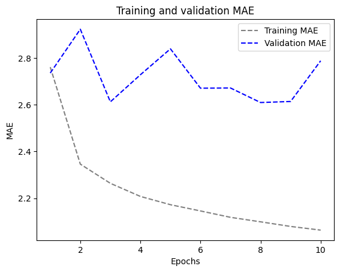

```python
loss = history.history["mae"]
val_loss = history.history["val_mae"]

epochs = range(1, len(loss) + 1)
plt.figure()
plt.plot(epochs, loss, color="grey", linestyle="dashed", label="Training MAE")
plt.plot(epochs,  val_loss, color="blue",linestyle="dashed", label="Validation MAE")
plt.title("Training and validation MAE")
plt.xlabel("Epochs")
plt.ylabel("MAE")
plt.legend()
plt.show()
```

```python
model = keras.models.load_model("jena_dense_model2.keras")
print(f"Validation MAE: {model.evaluate(val_dataset)[1]:.2f}")
```

```
Validation MAE: 2.61
```

Model 2 which is a simple dense connected layer neural network which has a validation MAE of 2.61 which is worse than the naive model. It seems like our common sense is doing a better job than the simple neural network here. This seems to be overfitting for sure as the training and validaiton losses deviate after 1st epoch.

Probably time to try a Recurrent neural network now.

# Model 3: training a GRU model

```python
inputs = keras.Input(shape=(sequence_length, float_data.shape[-1]))
x = layers.GRU(16)(inputs)
outputs = layers.Dense(1)(x)
model = keras.Model(inputs, outputs)

callbacks = [
    keras.callbacks.ModelCheckpoint("jena_gru_model3.keras",
                                    save_best_only=True)
]
model.compile(optimizer="rmsprop", loss="mse", metrics=["mae"])
history = model.fit(train_dataset,
                    epochs=10,
                    validation_data=val_dataset,
                    callbacks=callbacks)

model = keras.models.load_model("jena_gru_model3.keras")
print(f"Validation MAE: {model.evaluate(val_dataset)[1]:.2f}")
```

```
Validation MAE: 2.33
```

# Validation MAE for the Model 3 is around 2.33 which is definitely an improvement over the Naive model which has MAE of 2.44

Plotting the validation and train MAE over the number of epochs to see if the overfitting still exists

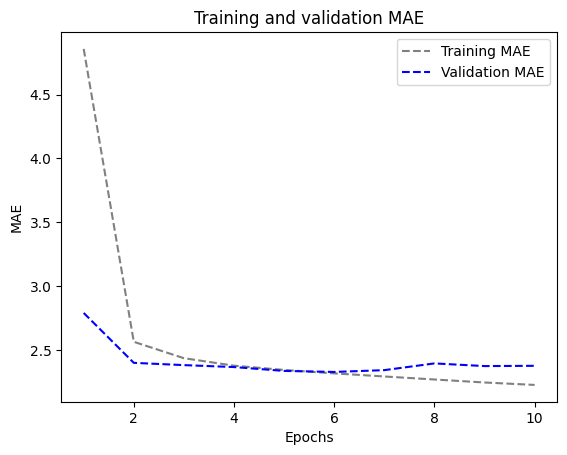

```python
loss = history.history["mae"]
val_loss = history.history["val_mae"]

epochs = range(1, len(loss) + 1)
plt.figure()
plt.plot(epochs, loss, color="grey", linestyle="dashed", label="Training MAE")
plt.plot(epochs,  val_loss, color="blue",linestyle="dashed", label="Validation MAE")
plt.title("Training and validation MAE")
plt.xlabel("Epochs")
plt.ylabel("MAE")
plt.legend()
plt.show()
```

This is so much better than the previous simple neural network and it seems like the validation loss has deviated a bit in the last few number of epochs(but is consistent)

Let's see if adding recurrent dropout and dropout regularization to this improves the model a bit more or at least prevents overfitting to the fullest

# Model 4: Adding recurrent dropout and dropout

```python
inputs = keras.Input(shape=(sequence_length, float_data.shape[-1]))
x = layers.GRU(16, dropout=0.2, recurrent_dropout=0.2)(inputs)  # Added dropout and recurrent_dropout
outputs = layers.Dense(1)(x)
model = keras.Model(inputs, outputs)

callbacks = [
    keras.callbacks.ModelCheckpoint("jena_gru_model4_with_dropout.keras", save_best_only=True)
]

model.compile(optimizer="rmsprop", loss="mse", metrics=["mae"])
history = model.fit(train_dataset, epochs=10, validation_data=val_dataset, callbacks=callbacks)

model = keras.models.load_model("jena_gru_model4_with_dropout.keras")
print(f"Validation MAE: {model.evaluate(val_dataset)[1]:.2f}")
```

```
Validation MAE: 2.37
```

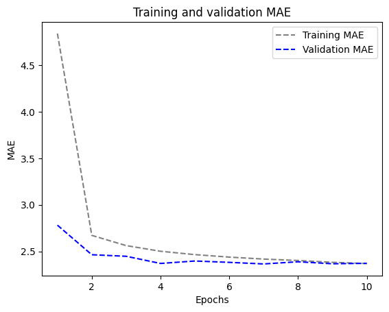

```python
loss = history.history["mae"]
val_loss = history.history["val_mae"]

epochs = range(1, len(loss) + 1)
plt.figure()
plt.plot(epochs, loss, color="grey", linestyle="dashed", label="Training MAE")
plt.plot(epochs,  val_loss, color="blue",linestyle="dashed", label="Validation MAE")
plt.title("Training and validation MAE")
plt.xlabel("Epochs")
plt.ylabel("MAE")
plt.legend()
plt.show()
```

Model 4's validation MAE 2.37 is higher than previous model(2.33). It seems like this model with recurrent dropout and dropout did not improve the model but is definitely consistent over the number of epochs and did not deviate higher than the training MAE in the late epochs.

# Model 5 - Stacked recurrent layers(GRU 16 units, GRU 32 units) without dropout/recurrent dropout

```python
# Define the model
inputs = keras.Input(shape=(sequence_length, float_data.shape[-1]))
x = layers.GRU(16, return_sequences=True)(inputs)
x = layers.GRU(32)(x)
outputs = layers.Dense(1)(x)
model = keras.Model(inputs, outputs)

# Compile the model
model.compile(optimizer="rmsprop", loss="mse", metrics=["mae"])

# Define callbacks
callbacks = [
    keras.callbacks.ModelCheckpoint("stacked_gru_model5_w_16_32.keras", save_best_only=True)
]

# Train the model
history = model.fit(train_dataset, epochs=10, validation_data=val_dataset, callbacks=callbacks)

# Evaluate the model
model = keras.models.load_model("stacked_gru_model5_w_16_32.keras")
validation_mae = model.evaluate(val_dataset)[1]

print(f"Validation MAE: {validation_mae:.2f}")
```

```
Validation MAE: 2.30
```

Model 5: Stacked GRU layers with 16, 32 units without dropout seems to be performing better than the previous models with validation MAE of 2.30. This is the best model so far.

Let us check how the training/validation mae evolved over the number of epochs:

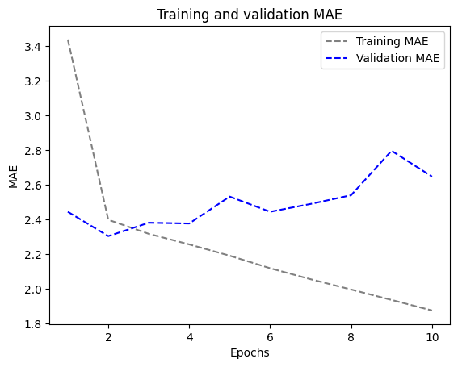

```python
loss = history.history["mae"]
val_loss = history.history["val_mae"]

epochs = range(1, len(loss) + 1)
plt.figure()
plt.plot(epochs, loss, color="grey", linestyle="dashed", label="Training MAE")
plt.plot(epochs,  val_loss, color="blue",linestyle="dashed", label="Validation MAE")
plt.title("Training and validation MAE")
plt.xlabel("Epochs")
plt.ylabel("MAE")
plt.legend()
plt.show()
```

It seems like the model is definitely overfitting as the validation MAE is growing higher over the number of epochs. We will now try Model 6 where we increase the units in first GRU layer of stacked GRU layers and see how the model performance change. Once we figure out which stacked layers configuration is performing best, we can probably apply dropout on the best model and see how that changes.

# Model 6: 2 Stacked GRU layers, with 32 and 32 units respectively without dropout/recurrent dropout

```python
# Define the model
inputs = keras.Input(shape=(sequence_length, float_data.shape[-1]))
x = layers.GRU(32, return_sequences=True)(inputs)
x = layers.GRU(32)(x)
outputs = layers.Dense(1)(x)
model = keras.Model(inputs, outputs)

# Compile the model
model.compile(optimizer="rmsprop", loss="mse", metrics=["mae"])

# Define callbacks
callbacks = [
    keras.callbacks.ModelCheckpoint("stacked_gru_model6_w_32_32.keras", save_best_only=True)
]

# Train the model
history = model.fit(train_dataset, epochs=10, validation_data=val_dataset, callbacks=callbacks)

# Evaluate the model
model = keras.models.load_model("stacked_gru_model6_w_32_32.keras")
validation_mae = model.evaluate(val_dataset)[1]

print(f"Validation MAE: {validation_mae:.2f}")
```

```
Validation MAE: 2.35
```

Model 6: Stacked GRU layers with 32, 32 units without dropout seems to be performing worse than the previous model with validation MAE of 2.35.

It seems like as we increased the units in the first GRU layer and keeping the same units in the second layers worsened the performance

Let us check how the training/validation mae evolved over the number of epochs:

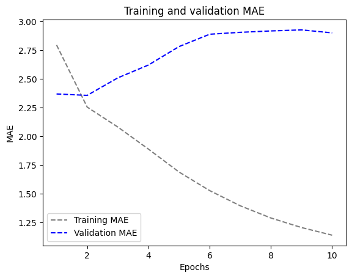

```python
loss = history.history["mae"]
val_loss = history.history["val_mae"]

epochs = range(1, len(loss) + 1)
plt.figure()
plt.plot(epochs, loss, color="grey", linestyle="dashed", label="Training MAE")
plt.plot(epochs,  val_loss, color="blue",linestyle="dashed", label="Validation MAE")
plt.title("Training and validation MAE")
plt.xlabel("Epochs")
plt.ylabel("MAE")
plt.legend()
plt.show()
```

It seems like the model is definitely overfitting as the validation MAE is growing higher over the number of epochs. We will now try Model 7 where we increase the units in second GRU layer of stacked GRU layers while keeping the first layer units the same and see how the model performance changes.

# Model 7: 2 Stacked GRU layers, with 32 and 64 units respectively without dropout/recurrent dropout

```python
# Define the model
inputs = keras.Input(shape=(sequence_length, float_data.shape[-1]))
x = layers.GRU(32, return_sequences=True)(inputs)
x = layers.GRU(64)(x)
outputs = layers.Dense(1)(x)
model = keras.Model(inputs, outputs)

# Compile the model
model.compile(optimizer="rmsprop", loss="mse", metrics=["mae"])

# Define callbacks
callbacks = [
    keras.callbacks.ModelCheckpoint("stacked_gru_model7_w_32_64.keras", save_best_only=True)
]

# Train the model
history = model.fit(train_dataset, epochs=10, validation_data=val_dataset, callbacks=callbacks)

# Evaluate the model
model = keras.models.load_model("stacked_gru_model7_w_32_64.keras")
validation_mae = model.evaluate(val_dataset)[1]

print(f"Validation MAE: {validation_mae:.2f}")
```

```
Validation MAE: 2.33
```

Model 7: Stacked GRU layers with 32, 64 units without dropout seems to be performing better than the Model 6 with validation MAE of 2.33, but worse than the Model 5 which is the best performer so far.

It seems like as we increased the units in the second GRU layer and keeping the same units in the first layer improved the performance

Let us check how the training/validation mae evolved over the number of epochs:

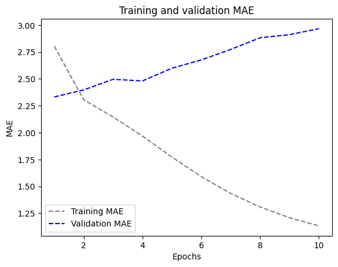

```python
loss = history.history["mae"]
val_loss = history.history["val_mae"]

epochs = range(1, len(loss) + 1)
plt.figure()
plt.plot(epochs, loss, color="grey", linestyle="dashed", label="Training MAE")
plt.plot(epochs,  val_loss, color="blue",linestyle="dashed", label="Validation MAE")
plt.title("Training and validation MAE")
plt.xlabel("Epochs")
plt.ylabel("MAE")
plt.legend()
plt.show()
```

It seems like this model is definitely overfitting again as the validation MAE deviates after 2nd epoch.

Let's use the best stacking model configuration above which is: stacked GRU layers with 16 and 32 units and apply recurrent dropout and dropout to see if the validation MAE does not deviate from the training MAE

# Model 8: 2 Stacked GRU layers, with 16 and 32 units respectively with dropout/recurrent dropout

```python
# Define the model
inputs = keras.Input(shape=(sequence_length, float_data.shape[-1]))
x = layers.GRU(16, dropout = 0.1, recurrent_dropout = 0.5, return_sequences=True)(inputs)
x = layers.GRU(32, activation='relu', dropout=0.1, recurrent_dropout=0.5)(x)
outputs = layers.Dense(1)(x)
model = keras.Model(inputs, outputs)

# Compile the model
model.compile(optimizer="rmsprop", loss="mse", metrics=["mae"])

# Define callbacks
callbacks = [
    keras.callbacks.ModelCheckpoint("stacked_gru_model8_w_16_32_w_dropout.keras", save_best_only=True)
]

# Train the model
history = model.fit(train_dataset, epochs=10, validation_data=val_dataset, callbacks=callbacks)

# Evaluate the model
model = keras.models.load_model("stacked_gru_model8_w_16_32_w_dropout.keras")
validation_mae = model.evaluate(val_dataset)[1]

print(f"Validation MAE: {validation_mae:.2f}")
```

```
Validation MAE: 2.40
```

Let us check how the training/validation mae evolved over the number of epochs:

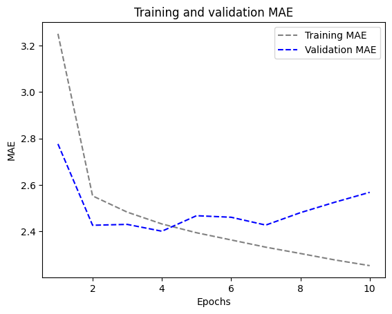

```python
loss = history.history["mae"]
val_loss = history.history["val_mae"]

epochs = range(1, len(loss) + 1)
plt.figure()
plt.plot(epochs, loss, color="grey", linestyle="dashed", label="Training MAE")
plt.plot(epochs,  val_loss, color="blue",linestyle="dashed", label="Validation MAE")
plt.title("Training and validation MAE")
plt.xlabel("Epochs")
plt.ylabel("MAE")
plt.legend()
plt.show()
```

This definitely reduced the overfitting as the validation MAE did not deviate much from the training MAE,however there still seems to be some overfitting using this model.

Lets use LSTM layers from now on starting with the simple LSTM model

# Model 9 : Using simple LSTM model

```python
inputs = keras.Input(shape=(sequence_length, float_data.shape[-1]))
x = layers.LSTM(16)(inputs)
outputs = layers.Dense(1)(x)
model = keras.Model(inputs, outputs)

callbacks = [
    keras.callbacks.ModelCheckpoint("jena_lstm_model9.keras",
                                    save_best_only=True)
]
model.compile(optimizer="rmsprop", loss="mse", metrics=["mae"])
history = model.fit(train_dataset,
                    epochs=10,
                    validation_data=val_dataset,
                    callbacks=callbacks)

model = keras.models.load_model("jena_lstm_model9.keras")
print(f"Validation MAE: {model.evaluate(val_dataset)[1]:.2f}")
```

```
Validation MAE: 2.38
```

The simple LSTM model(Model 9) MAE is 2.38 which is higher than the simple GRU model(Model 3). It seems like GRU model seems to be doing well for this time series task.

Lets check how the Validation and Training MAE varies by the number of epochs

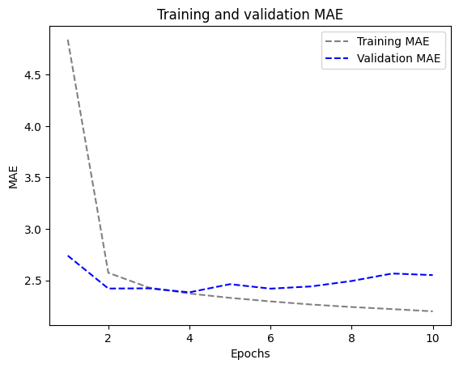

```python
loss = history.history["mae"]
val_loss = history.history["val_mae"]

epochs = range(1, len(loss) + 1)
plt.figure()
plt.plot(epochs, loss, color="grey", linestyle="dashed", label="Training MAE")
plt.plot(epochs,  val_loss, color="blue",linestyle="dashed", label="Validation MAE")
plt.title("Training and validation MAE")
plt.xlabel("Epochs")
plt.ylabel("MAE")
plt.legend()
plt.show()
```

The validation MAE deviates from training MAE after 4th epoch which suggests that there is overfitting. Lets add recurrent dropout and dropout to the simple LSTM model and see if that performs better or worse.

# Model 10 - Simple LSTM with dropout/recurrent dropout

```python
inputs = keras.Input(shape=(sequence_length, float_data.shape[-1]))
x = layers.LSTM(16, dropout=0.2, recurrent_dropout=0.2)(inputs)  # Added dropout and recurrent_dropout
outputs = layers.Dense(1)(x)
model = keras.Model(inputs, outputs)

callbacks = [
    keras.callbacks.ModelCheckpoint("jena_lstm_model10_with_dropout.keras", save_best_only=True)
]

model.compile(optimizer="rmsprop", loss="mse", metrics=["mae"])
history = model.fit(train_dataset, epochs=10, validation_data=val_dataset, callbacks=callbacks)

model = keras.models.load_model("jena_lstm_model10_with_dropout.keras")
print(f"Validation MAE: {model.evaluate(val_dataset)[1]:.2f}")
```

```
Validation MAE: 2.42
```

Model 10's MAE is 2.42 which is higher than the model without dropout and is performing worse than the previous model, but lets see if the validation MAE Is closer to training MAE as per the MAE vs epochs graph below

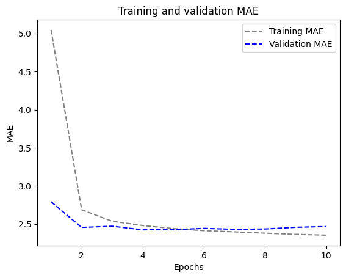

```python
loss = history.history["mae"]
val_loss = history.history["val_mae"]

epochs = range(1, len(loss) + 1)
plt.figure()
plt.plot(epochs, loss, color="grey", linestyle="dashed", label="Training MAE")
plt.plot(epochs,  val_loss, color="blue",linestyle="dashed", label="Validation MAE")
plt.title("Training and validation MAE")
plt.xlabel("Epochs")
plt.ylabel("MAE")
plt.legend()
plt.show()
```

This model definitely removed overfitting, but the performance is worse than the model without recurrent dropout.

Lets try stacking the LSTM layers without dropout and see if the model performs better.

# Model 11 - 2 Stacked LSTM layers with 16, 32 units in layers respectively

```python
# Define the model
inputs = keras.Input(shape=(sequence_length, float_data.shape[-1]))
x = layers.LSTM(16, return_sequences=True)(inputs)
x = layers.LSTM(32)(x)
outputs = layers.Dense(1)(x)
model = keras.Model(inputs, outputs)

# Compile the model
model.compile(optimizer="rmsprop", loss="mse", metrics=["mae"])

# Define callbacks
callbacks = [
    keras.callbacks.ModelCheckpoint("stacked_lstm_model11_w_16_32.keras", save_best_only=True)
]

# Train the model
history = model.fit(train_dataset, epochs=10, validation_data=val_dataset, callbacks=callbacks)

# Evaluate the model
model = keras.models.load_model("stacked_lstm_model11_w_16_32.keras")
validation_mae = model.evaluate(val_dataset)[1]

print(f"Validation MAE: {validation_mae:.2f}")
```

```
Validation MAE: 2.45
```

Model 11's MAE is 2.45 which is higher than the model 10 without stacking and is performing worse.

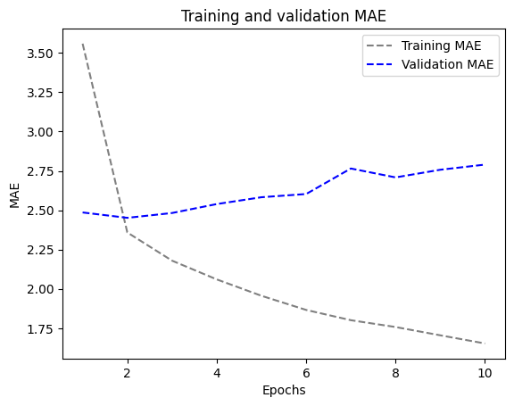

```python
loss = history.history["mae"]
val_loss = history.history["val_mae"]

epochs = range(1, len(loss) + 1)
plt.figure()
plt.plot(epochs, loss, color="grey", linestyle="dashed", label="Training MAE")
plt.plot(epochs,  val_loss, color="blue",linestyle="dashed", label="Validation MAE")
plt.title("Training and validation MAE")
plt.xlabel("Epochs")
plt.ylabel("MAE")
plt.legend()
plt.show()
```

We did not add dropout which made the validation MAE deviate a lot from the training MAE. As a next step we will try stacking with 32, 32 units. Increasing the units in the first layer keeping the second layers units the same.

# Model 12 - Stacked LSTM layers with 32, 32 units respectively

```python
# Define the model
inputs = keras.Input(shape=(sequence_length, float_data.shape[-1]))
x = layers.LSTM(32, return_sequences=True)(inputs)
x = layers.LSTM(32)(x)
outputs = layers.Dense(1)(x)
model = keras.Model(inputs, outputs)

# Compile the model
model.compile(optimizer="rmsprop", loss="mse", metrics=["mae"])

# Define callbacks
callbacks = [
    keras.callbacks.ModelCheckpoint("stacked_lstm_model12_w_32_32.keras", save_best_only=True)
]

# Train the model
history = model.fit(train_dataset, epochs=10, validation_data=val_dataset, callbacks=callbacks)

# Evaluate the model
model = keras.models.load_model("stacked_lstm_model12_w_32_32.keras")
validation_mae = model.evaluate(val_dataset)[1]

print(f"Validation MAE: {validation_mae:.2f}")
```

```
Validation MAE: 2.47
```

Model 12's MAE is higher and is performing worse than the stacked with 16, 32(previous model 11). This is similar to what we found with respect to GRU models above.

[figure not shown]

```python
loss = history.history["mae"]
val_loss = history.history["val_mae"]

epochs = range(1, len(loss) + 1)
plt.figure()
plt.plot(epochs, loss, color="grey", linestyle="dashed", label="Training MAE")
plt.plot(epochs,  val_loss, color="blue",linestyle="dashed", label="Validation MAE")
plt.title("Training and validation MAE")
plt.xlabel("Epochs")
plt.ylabel("MAE")
plt.legend()
plt.show()
```

We did not add dropout which made the validation MAE deviate a lot from the training MAE. As a next step we will try stacking with 32, 64 units. Increasing the units in the second layer keeping the first layer units the same. As per GRU, this improved from the 32,32. Let's see if that is the case in LSTM stacked layers as well

# Model 13 - Stacked LSTM layers with 32, 64 units respectively

```python
# Define the model
inputs = keras.Input(shape=(sequence_length, float_data.shape[-1]))
x = layers.LSTM(32, return_sequences=True)(inputs)
x = layers.LSTM(64)(x)
outputs = layers.Dense(1)(x)
model = keras.Model(inputs, outputs)

# Compile the model
model.compile(optimizer="rmsprop", loss="mse", metrics=["mae"])

# Define callbacks
callbacks = [
    keras.callbacks.ModelCheckpoint("stacked_lstm_model13_w_32_64.keras", save_best_only=True)
]

# Train the model
history = model.fit(train_dataset, epochs=10, validation_data=val_dataset, callbacks=callbacks)

# Evaluate the model
model = keras.models.load_model("stacked_lstm_model13_w_32_64.keras")
validation_mae = model.evaluate(val_dataset)[1]

print(f"Validation MAE: {validation_mae:.2f}")
```

```
Validation MAE: 2.50
```

Stacked LSTM with 32, 64's MAE is 2.50 which is higher than previous models and is performing worse.

Unlike GRU layers above, in terms of stacked LSTM layers, increasing second layer units performed worse than not increasing the second layer units.

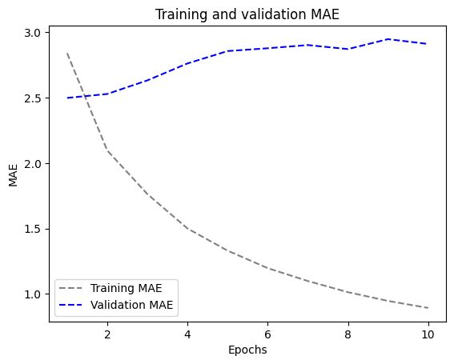

```python
loss = history.history["mae"]
val_loss = history.history["val_mae"]

epochs = range(1, len(loss) + 1)
plt.figure()
plt.plot(epochs, loss, color="grey", linestyle="dashed", label="Training MAE")
plt.plot(epochs,  val_loss, color="blue",linestyle="dashed", label="Validation MAE")
plt.title("Training and validation MAE")
plt.xlabel("Epochs")
plt.ylabel("MAE")
plt.legend()
plt.show()
```

Also the overfitting is very high in this model. Even if we apply dropout to the best stacked LSTM layers, i am not confident that it could reduce the MAE more, as the dropout is not doing much to the LSTM layers compared to what we saw in GRU layers above. Stacked GRU layers after applying dropout did not reduce the MAE, so i would think there will not be any reduction in MAE with LSTM layers as well.

I am going to use 1D conv nets along with the LSTM/GRU Layers to see how big of a performance boost/decrease that is going to give.

Starting with basic 1D conv net

# Model 14 - 1 D conv net

```python
# Define your model
inputs = keras.Input(shape=(sequence_length, float_data.shape[-1]))
x = layers.Conv1D(16, 5, activation="relu")(inputs)
x = layers.MaxPooling1D(2)(x)
x = layers.Conv1D(32, 3, activation="relu")(x)
x = layers.MaxPooling1D(2)(x)
x = layers.Conv1D(64, 3, activation="relu")(x)
x = layers.GlobalAveragePooling1D()(x)
x = layers.Dense(128, activation="relu")(x)
outputs = layers.Dense(1)(x)

model = keras.Model(inputs, outputs)

# Compile the model
model.compile(optimizer="rmsprop", loss="mse", metrics=["mae"])

# Train the model
callbacks = [
    keras.callbacks.ModelCheckpoint("simple_1d_conv_net_model14.keras", save_best_only=True)
]

history = model.fit(train_dataset,
                    epochs=10,
                    validation_data=val_dataset,
                    callbacks=callbacks)

# Evaluate the model
model = keras.models.load_model("simple_1d_conv_net_model14.keras")
validation_mae = model.evaluate(val_dataset)[1]
print(f"Validation MAE: {validation_mae:.2f}")
```

```
Validation MAE: 3.00
```

It seems like 1D conv nets are not that great at time series forecasting compared to using recurrent neural networks, as the validation MAE is 3 which is way higher than the best model's MAE: 2.3(Stacked GRU with 16, 32 units without dropout)

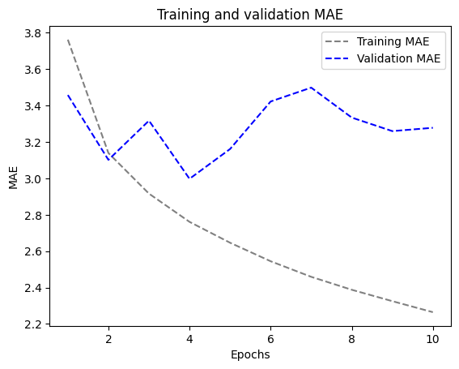

```python
loss = history.history["mae"]
val_loss = history.history["val_mae"]
epochs = range(1, len(loss) + 1)
plt.figure()
plt.plot(epochs, loss, color="grey", linestyle="dashed", label="Training MAE")
plt.plot(epochs,  val_loss, color="blue",linestyle="dashed", label="Validation MAE")
plt.title("Training and validation MAE")
plt.xlabel("Epochs")
plt.ylabel("MAE")
plt.legend()
plt.show()
```

Also, this model seems to be overfitting. The model's MAE is also super high and perhaps adding a GRU/LSTM might help with the model performance

# Model 15 - 1D Conv net plus LSTM

```python
inputs = keras.Input(shape=(sequence_length, float_data.shape[-1]))

x = layers.Conv1D(16, 5, activation="relu")(inputs)
x = layers.MaxPooling1D(2)(x)
x = layers.Conv1D(32, 3, activation="relu")(x)
x = layers.MaxPooling1D(2)(x)
x = layers.Conv1D(64, 3, activation="relu")(x)
x = layers.GlobalAveragePooling1D()(x)
x = layers.Reshape((-1, 64))(x)  # Reshape the data to be 3D
x = layers.LSTM(16)(x)
outputs = layers.Dense(1)(x)
model = keras.Model(inputs, outputs)

model.compile(optimizer="rmsprop", loss="mse", metrics=["mae"])

callbacks = [
    keras.callbacks.ModelCheckpoint("jena_1d_Conv_LSTM_model15.keras", save_best_only=True)
]

history = model.fit(train_dataset, epochs=10, validation_data=val_dataset, callbacks=callbacks)

model = keras.models.load_model("jena_1d_Conv_LSTM_model15.keras")
print(f"Validation MAE: {model.evaluate(val_dataset)[1]:.2f}")
```

```
Validation MAE: 2.86
```

The validation MAE is 2.86 and it seems like adding LSTM did provide a significant improvement on MAE and decreased from 3 to 2.86. Lets check if model is prone to overfitting here.

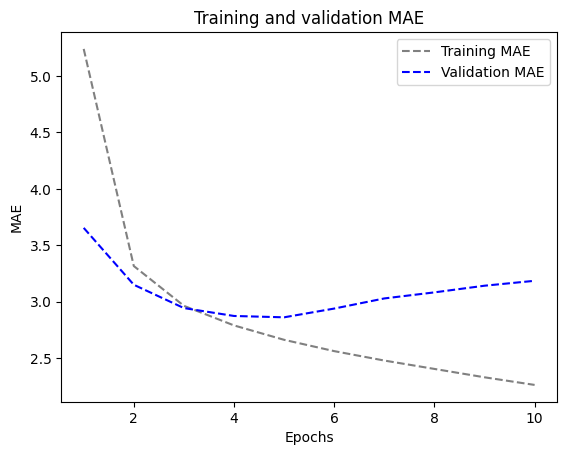

```python
loss = history.history["mae"]
val_loss = history.history["val_mae"]

epochs = range(1, len(loss) + 1)
plt.figure()
plt.plot(epochs, loss, color="grey", linestyle="dashed", label="Training MAE")
plt.plot(epochs,  val_loss, color="blue",linestyle="dashed", label="Validation MAE")
plt.title("Training and validation MAE")
plt.xlabel("Epochs")
plt.ylabel("MAE")
plt.legend()
plt.show()
```

Yes, the model seems to be overfitting as the validation MAE deviates after 4th epoch.

Lets try adding GRU unit to see if the model performs better or worse:

# Model 16 - 1D Conv net + GRU

```python
inputs = keras.Input(shape=(sequence_length, float_data.shape[-1]))

x = layers.Conv1D(16, 5, activation="relu")(inputs)
x = layers.MaxPooling1D(2)(x)
x = layers.Conv1D(32, 3, activation="relu")(x)
x = layers.MaxPooling1D(2)(x)
x = layers.Conv1D(64, 3, activation="relu")(x)
x = layers.GlobalAveragePooling1D()(x)
x = layers.Reshape((-1, 64))(x)  # Reshape the data to be 3D
x = layers.GRU(16)(x)
outputs = layers.Dense(1)(x)
model = keras.Model(inputs, outputs)

model.compile(optimizer="rmsprop", loss="mse", metrics=["mae"])

callbacks = [
    keras.callbacks.ModelCheckpoint("jena_1d_Conv_GRU_model16.keras", save_best_only=True)
]

history = model.fit(train_dataset, epochs=10, validation_data=val_dataset, callbacks=callbacks)

model = keras.models.load_model("jena_1d_Conv_GRU_model16.keras")
print(f"Validation MAE: {model.evaluate(val_dataset)[1]:.2f}")
```

```
Validation MAE: 2.93
```

Surprisingly, 1D conv net with LSTM performs better than 1D conv net with GRU. But they both have MAE way higher than the best model

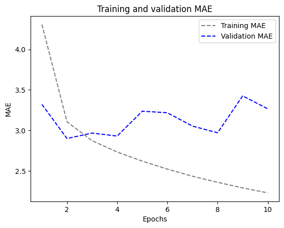

```python
loss = history.history["mae"]
val_loss = history.history["val_mae"]

epochs = range(1, len(loss) + 1)
plt.figure()
plt.plot(epochs, loss, color="grey", linestyle="dashed", label="Training MAE")
plt.plot(epochs,  val_loss, color="blue",linestyle="dashed", label="Validation MAE")
plt.title("Training and validation MAE")
plt.xlabel("Epochs")
plt.ylabel("MAE")
plt.legend()
plt.show()
```

# Out of all the 16 models tried as per the assignment instructions, the best model seems to be the Stacked GRU layers with 16, 32 units without dropout as per the validation MAE.

# Lets evaluate this model on the test dataset

```python
model = keras.models.load_model("stacked_gru_model5_w_16_32.keras")
test_mae = model.evaluate(test_dataset)[1]

print(f"Test MAE: {test_mae:.2f}")
```

```
Test MAE: 2.45
```

# Final testing dataset Mean Absolute error using our best model(Model 5) is 2.45